# ANCOVA in Writing (TDE) (Writing (TDE))

Geiser C. Challco geiser@alumni.usp.br

- Setting Initial Variables
- Descriptive Statistics of Initial Data
- ANCOVA and Pairwise for one factor: **grupo**
  - Without remove non-normal data
  - Computing ANCOVA and PairWise After removing non-normal data (OK)
    - Plots for ancova
    - Checking linearity assumption
    - Checking normality and homogeneity
- ANCOVA and Pairwise for two factors **grupo:Sexo**
  - Without remove non-normal data
  - Computing ANCOVA and PairWise After removing non-normal data (OK)
    - Plots for ancova
    - Checking linearity assumption
    - Checking normality and homogeneity
- ANCOVA and Pairwise for two factors **grupo:Zona**
  - Without remove non-normal data
  - Computing ANCOVA and PairWise After removing non-normal data (OK)
    - Plots for ancova
    - Checking linearity assumption
    - Checking normality and homogeneity
- ANCOVA and Pairwise for two factors **grupo:Cor.Raca**
  - Without remove non-normal data
  - Computing ANCOVA and PairWise After removing non-normal data (OK)
    - Plots for ancova
    - Checking linearity assumption
    - Checking normality and homogeneity
- ANCOVA and Pairwise for two factors **grupo:Serie**
  - Without remove non-normal data
  - Computing ANCOVA and PairWise After removing non-normal data (OK)
    - Plots for ancova
    - Checking linearity assumption
    - Checking normality and homogeneity
- ANCOVA and Pairwise for two factors **grupo:score.tde.quintile**
  - Without remove non-normal data
  - Computing ANCOVA and PairWise After removing non-normal data (OK)
    - Plots for ancova
    - Checking linearity assumption
    - Checking normality and homogeneity
- Summary of Results
  - Descriptive Statistics
  - ANCOVA Table Comparison
  - PairWise Table Comparison
  - EMMS Table Comparison

**NOTE**:

- Teste ANCOVA para determinar se houve diferenças significativas no Writing (TDE) (medido usando pre- e pos-testes).
- ANCOVA test to determine whether there were significant differences in Writing (TDE) (measured using pre- and post-tests).

# Setting Initial Variables

```r
dv = "score.tde"
dv.pos = "score.tde.pos"
dv.pre = "score.tde.pre"

fatores2 <- c("Sexo","Zona","Cor.Raca","Serie","score.tde.quintile")
lfatores2 <- as.list(fatores2)
names(lfatores2) <- fatores2

fatores1 <- c("grupo", fatores2)
lfatores1 <- as.list(fatores1)
names(lfatores1) <- fatores1

lfatores <- c(lfatores1)

color <- list()
color[["prepost"]] = c("#ffee65","#f28e2B")
color[["grupo"]] = c("#bcbd22","#008000")
color[["Sexo"]] = c("#FF007F","#4D4DFF")
color[["Zona"]] = c("#AA00FF","#00CCCC")
color[["Cor.Raca"]] = c(
  "Parda"="#b97100","Indígena"="#9F262F",
  "Branca"="#87c498", "Preta"="#848283","Amarela"="#D6B91C"
)

level <- list()
level[["grupo"]] = c("Controle","Experimental")
level[["Sexo"]] = c("F","M")
level[["Zona"]] = c("Rural","Urbana")
level[["Cor.Raca"]] = c("Parda","Indígena","Branca", "Preta","Amarela")
level[["Serie"]] = c("6 ano","7 ano","8 ano","9 ano")

# ..

ymin <- 0
ymax <- 0

ymin.ci <- 0
ymax.ci <- 0


color[["grupo:Sexo"]] = c(
  "Controle:F"="#ff99cb", "Controle:M"="#b7b7ff",
  "Experimental:F"="#FF007F", "Experimental:M"="#4D4DFF",
  "Controle.F"="#ff99cb", "Controle.M"="#b7b7ff",
  "Experimental.F"="#FF007F", "Experimental.M"="#4D4DFF"
)
color[["grupo:Zona"]] = c(
  "Controle:Rural"="#b2efef","Controle:Urbana"="#e5b2ff",
  "Experimental:Rural"="#00CCCC", "Experimental:Urbana"="#AA00FF",
  "Controle.Rural"="#b2efef","Controle.Urbana"="#e5b2ff",
  "Experimental.Rural"="#00CCCC", "Experimental.Urbana"="#AA00FF"
)
color[["grupo:Cor.Raca"]] = c(
    "Controle:Parda"="#e3c699", "Experimental:Parda"="#b97100",
    "Controle:Indígena"="#e2bdc0", "Experimental:Indígena"="#9F262F",
    "Controle:Branca"="#c0e8cb", "Experimental:Branca"="#87c498",
    "Controle:Preta"="#dad9d9", "Experimental:Preta"="#848283",
    "Controle:Amarela"="#eee3a4", "Experimental:Amarela"="#D6B91C",

    "Controle.Parda"="#e3c699", "Experimental.Parda"="#b97100",
    "Controle.Indígena"="#e2bdc0", "Experimental.Indígena"="#9F262F",
    "Controle.Branca"="#c0e8cb", "Experimental.Branca"="#87c498",
    "Controle.Preta"="#dad9d9", "Experimental.Preta"="#848283",
    "Controle.Amarela"="#eee3a4", "Experimental.Amarela"="#D6B91C"
)


for (coln in c("vocab","vocab.teach","vocab.non.teach","score.tde",
               "TFL.lidas.per.min","TFL.corretas.per.min","TFL.erradas.per.min","TFL.omitidas.per.min",
               "leitura.compreensao")) {
  color[[paste0(coln,".quintile")]] = c("#BF0040","#FF0000","#800080","#0000FF","#4000BF")
  level[[paste0(coln,".quintile")]] = c("1st quintile","2nd quintile","3rd quintile","4th quintile","5th quintile")
  color[[paste0("grupo:",coln,".quintile")]] = c(
    "Experimental.1st quintile"="#BF0040", "Controle.1st quintile"="#d8668c",
    "Experimental.2nd quintile"="#FF0000", "Controle.2nd quintile"="#ff7f7f",
    "Experimental.3rd quintile"="#8fce00", "Controle.3rd quintile"="#ddf0b2",
    "Experimental.4th quintile"="#0000FF", "Controle.4th quintile"="#b2b2ff",
    "Experimental.5th quintile"="#4000BF", "Controle.5th quintile"="#b299e5",

    "Experimental:1st quintile"="#BF0040", "Controle:1st quintile"="#d8668c",
    "Experimental:2nd quintile"="#FF0000", "Controle:2nd quintile"="#ff7f7f",
    "Experimental:3rd quintile"="#8fce00", "Controle:3rd quintile"="#ddf0b2",
    "Experimental:4th quintile"="#0000FF", "Controle:4th quintile"="#b2b2ff",
    "Experimental:5th quintile"="#4000BF", "Controle:5th quintile"="#b299e5")
}


gdat <- read_excel("../data/data.xlsx", sheet = "sumary")
gdat <- gdat[which(is.na(gdat$Necessidade.Deficiencia) & !is.na(gdat$WG.Grupo)),]



dat <- gdat
dat$grupo <- factor(dat[["WG.Grupo"]], level[["grupo"]])
for (coln in c(names(lfatores))) {
  dat[[coln]] <- factor(dat[[coln]], level[[coln]][level[[coln]] %in% unique(dat[[coln]])])
}
dat <- dat[which(!is.na(dat[[dv.pre]]) & !is.na(dat[[dv.pos]])),]
dat <- dat[,c("id",names(lfatores),dv.pre,dv.pos)]

dat.long <- rbind(dat, dat)
dat.long$time <- c(rep("pre", nrow(dat)), rep("pos", nrow(dat)))
dat.long$time <- factor(dat.long$time, c("pre","pos"))
dat.long[[dv]] <- c(dat[[dv.pre]], dat[[dv.pos]])


for (f in c("grupo", names(lfatores))) {
  if (is.null(color[[f]]) && length(unique(dat[[f]])) > 0)
      color[[f]] <- distinctColorPalette(length(unique(dat[[f]])))
}
for (f in c(fatores2)) {
  if (is.null(color[[paste0("grupo:",f)]]) && length(unique(dat[[f]])) > 0)
    color[[paste0("grupo:",f)]] <- distinctColorPalette(length(unique(dat[["grupo"]]))*length(unique(dat[[f]])))
}

ldat <- list()
laov <- list()
lpwc <- list()
lemms <- list()
```

# Descriptive Statistics of Initial Data

```r
df <- get.descriptives(dat, c(dv.pre, dv.pos), c("grupo"),
                       include.global = T, symmetry.test = T, normality.test = F)
df <- plyr::rbind.fill(
  df, do.call(plyr::rbind.fill, lapply(lfatores2, FUN = function(f) {
    if (nrow(dat) > 0 && sum(!is.na(unique(dat[[f]]))) > 1)
      get.descriptives(dat, c(dv.pre,dv.pos), c("grupo", f),
                       symmetry.test = T, normality.test = F)
    }))
)
df <- df[,c(fatores1[fatores1 %in% colnames(df)],"variable",
            colnames(df)[!colnames(df) %in% c(fatores1,"variable")])]
```

| grupo | Sexo | Zona | Cor.Raca | Serie | score.tde.quintile | variable | n | mean | median | min | max | sd | se | ci | iqr | symmetry | skewness | kurtosis |
| --- | --- | --- | --- | --- | --- | --- | --- | --- | --- | --- | --- | --- | --- | --- | --- | --- | --- | --- |
| Controle |  |  |  |  |  | score.tde.pre | 485 | 37.631 | 44.0 | 0 | 75 | 19.176 | 0.871 | 1.711 | 33.00 | YES | -0.443 | -1.017 |
| Experimental |  |  |  |  |  | score.tde.pre | 636 | 36.748 | 39.0 | 0 | 73 | 16.891 | 0.670 | 1.315 | 24.00 | YES | -0.303 | -0.711 |
|  |  |  |  |  |  | score.tde.pre | 1121 | 37.130 | 41.0 | 0 | 75 | 17.912 | 0.535 | 1.050 | 28.00 | YES | -0.370 | -0.857 |
| Controle |  |  |  |  |  | score.tde.pos | 485 | 33.816 | 36.0 | 0 | 73 | 20.988 | 0.953 | 1.873 | 37.00 | YES | -0.108 | -1.287 |
| Experimental |  |  |  |  |  | score.tde.pos | 636 | 35.376 | 38.0 | 0 | 74 | 18.900 | 0.749 | 1.472 | 30.00 | YES | -0.158 | -1.024 |
|  |  |  |  |  |  | score.tde.pos | 1121 | 34.701 | 37.0 | 0 | 74 | 19.836 | 0.592 | 1.162 | 33.00 | YES | -0.145 | -1.138 |
| Controle | F |  |  |  |  | score.tde.pre | 247 | 40.652 | 46.0 | 0 | 72 | 17.259 | 1.098 | 2.163 | 24.50 | NO | -0.692 | -0.519 |
| Controle | M |  |  |  |  | score.tde.pre | 238 | 34.496 | 42.0 | 0 | 75 | 20.552 | 1.332 | 2.624 | 37.00 | YES | -0.173 | -1.308 |
| Experimental | F |  |  |  |  | score.tde.pre | 319 | 39.408 | 43.0 | 0 | 73 | 16.802 | 0.941 | 1.851 | 25.00 | YES | -0.460 | -0.599 |
| Experimental | M |  |  |  |  | score.tde.pre | 317 | 34.073 | 36.0 | 0 | 71 | 16.580 | 0.931 | 1.832 | 23.00 | YES | -0.175 | -0.723 |
| Controle | F |  |  |  |  | score.tde.pos | 247 | 36.567 | 42.0 | 0 | 72 | 19.883 | 1.265 | 2.492 | 35.00 | YES | -0.290 | -1.208 |
| Controle | M |  |  |  |  | score.tde.pos | 238 | 30.962 | 28.5 | 0 | 73 | 21.752 | 1.410 | 2.778 | 37.00 | YES | 0.098 | -1.291 |
| Experimental | F |  |  |  |  | score.tde.pos | 319 | 38.138 | 42.0 | 0 | 73 | 19.397 | 1.086 | 2.137 | 32.00 | YES | -0.311 | -1.059 |
| Experimental | M |  |  |  |  | score.tde.pos | 317 | 32.596 | 34.0 | 0 | 74 | 17.992 | 1.011 | 1.988 | 29.00 | YES | -0.050 | -0.909 |
| Controle |  | Rural |  |  |  | score.tde.pre | 243 | 36.181 | 43.0 | 0 | 69 | 19.626 | 1.259 | 2.480 | 34.50 | YES | -0.429 | -1.220 |
| Controle |  | Urbana |  |  |  | score.tde.pre | 109 | 39.468 | 43.0 | 1 | 75 | 18.034 | 1.727 | 3.424 | 26.00 | YES | -0.361 | -0.676 |
| Controle |  |  |  |  |  | score.tde.pre | 133 | 38.774 | 45.0 | 0 | 73 | 19.183 | 1.663 | 3.290 | 32.00 | YES | -0.480 | -1.003 |
| Experimental |  | Rural |  |  |  | score.tde.pre | 284 | 34.592 | 35.5 | 0 | 73 | 17.467 | 1.036 | 2.040 | 25.25 | YES | -0.140 | -0.823 |
| Experimental |  | Urbana |  |  |  | score.tde.pre | 167 | 37.850 | 42.0 | 0 | 71 | 16.633 | 1.287 | 2.541 | 22.00 | YES | -0.491 | -0.519 |
| Experimental |  |  |  |  |  | score.tde.pre | 185 | 39.065 | 42.0 | 0 | 69 | 15.877 | 1.167 | 2.303 | 23.00 | YES | -0.345 | -0.691 |
| Controle |  | Rural |  |  |  | score.tde.pos | 243 | 34.243 | 39.0 | 0 | 72 | 21.515 | 1.380 | 2.719 | 38.00 | YES | -0.201 | -1.321 |
| Controle |  | Urbana |  |  |  | score.tde.pos | 109 | 29.835 | 26.0 | 0 | 73 | 20.374 | 1.951 | 3.868 | 37.00 | YES | 0.237 | -1.198 |
| Controle |  |  |  |  |  | score.tde.pos | 133 | 36.301 | 39.0 | 0 | 73 | 20.179 | 1.750 | 3.461 | 34.00 | YES | -0.200 | -1.185 |
| Experimental |  | Rural |  |  |  | score.tde.pos | 284 | 33.627 | 33.0 | 0 | 72 | 19.232 | 1.141 | 2.246 | 33.00 | YES | 0.039 | -1.088 |
| Experimental |  | Urbana |  |  |  | score.tde.pos | 167 | 34.108 | 38.0 | 0 | 74 | 18.899 | 1.462 | 2.887 | 30.50 | YES | -0.228 | -1.049 |
| Experimental |  |  |  |  |  | score.tde.pos | 185 | 39.205 | 42.0 | 0 | 73 | 17.909 | 1.317 | 2.598 | 26.00 | YES | -0.387 | -0.775 |
| Controle |  |  | Parda |  |  | score.tde.pre | 162 | 36.741 | 43.0 | 0 | 66 | 18.900 | 1.485 | 2.932 | 31.25 | NO | -0.595 | -0.975 |
| Controle |  |  | Indígena |  |  | score.tde.pre | 11 | 42.000 | 46.0 | 4 | 65 | 17.297 | 5.215 | 11.621 | 9.50 | NO | -1.005 | -0.104 |
| Controle |  |  | Branca |  |  | score.tde.pre | 50 | 41.460 | 46.0 | 2 | 67 | 16.942 | 2.396 | 4.815 | 14.50 | NO | -0.821 | -0.311 |
| Controle |  |  |  |  |  | score.tde.pre | 262 | 37.267 | 43.0 | 0 | 75 | 19.798 | 1.223 | 2.408 | 34.00 | YES | -0.268 | -1.181 |
| Experimental |  |  | Parda |  |  | score.tde.pre | 190 | 34.253 | 35.0 | 0 | 68 | 17.537 | 1.272 | 2.510 | 27.00 | YES | -0.133 | -0.931 |
| Experimental |  |  | Indígena |  |  | score.tde.pre | 15 | 27.067 | 26.0 | 6 | 54 | 17.065 | 4.406 | 9.450 | 27.00 | YES | 0.126 | -1.422 |
| Experimental |  |  | Branca |  |  | score.tde.pre | 61 | 34.623 | 36.0 | 0 | 73 | 19.728 | 2.526 | 5.053 | 33.00 | YES | -0.045 | -1.037 |
| Experimental |  |  | Amarela |  |  | score.tde.pre | 1 | 23.000 | 23.0 | 23 | 23 |  |  |  | 0.00 | few data | 0.000 | 0.000 |
| Experimental |  |  |  |  |  | score.tde.pre | 369 | 38.816 | 42.0 | 0 | 71 | 15.723 | 0.819 | 1.610 | 21.00 | YES | -0.438 | -0.449 |
| Controle |  |  | Parda |  |  | score.tde.pos | 162 | 32.463 | 35.0 | 0 | 68 | 20.798 | 1.634 | 3.227 | 39.75 | YES | -0.166 | -1.437 |
| Controle |  |  | Indígena |  |  | score.tde.pos | 11 | 45.636 | 52.0 | 4 | 63 | 19.931 | 6.009 | 13.390 | 19.50 | NO | -0.968 | -0.645 |
| Controle |  |  | Branca |  |  | score.tde.pos | 50 | 34.300 | 38.0 | 0 | 72 | 20.518 | 2.902 | 5.831 | 34.75 | YES | -0.208 | -1.184 |
| Controle |  |  |  |  |  | score.tde.pos | 262 | 34.065 | 34.0 | 0 | 73 | 21.180 | 1.309 | 2.577 | 36.00 | YES | -0.024 | -1.252 |
| Experimental |  |  | Parda |  |  | score.tde.pos | 190 | 32.447 | 30.0 | 0 | 71 | 19.467 | 1.412 | 2.786 | 32.75 | YES | 0.082 | -1.112 |
| Experimental |  |  | Indígena |  |  | score.tde.pos | 15 | 30.333 | 26.0 | 1 | 57 | 17.715 | 4.574 | 9.810 | 30.50 | YES | 0.117 | -1.542 |
| Experimental |  |  | Branca |  |  | score.tde.pos | 61 | 33.311 | 34.0 | 0 | 72 | 21.189 | 2.713 | 5.427 | 34.00 | YES | 0.076 | -1.201 |
| Experimental |  |  | Amarela |  |  | score.tde.pos | 1 | 23.000 | 23.0 | 23 | 23 |  |  |  | 0.00 | few data | 0.000 | 0.000 |
| Experimental |  |  |  |  |  | score.tde.pos | 369 | 37.463 | 40.0 | 0 | 74 | 18.045 | 0.939 | 1.847 | 27.00 | YES | -0.336 | -0.844 |
| Controle |  |  |  | 6 ano |  | score.tde.pre | 134 | 28.993 | 26.5 | 0 | 63 | 19.526 | 1.687 | 3.336 | 36.00 | YES | 0.057 | -1.526 |
| Controle |  |  |  | 7 ano |  | score.tde.pre | 141 | 34.716 | 41.0 | 0 | 69 | 17.842 | 1.503 | 2.971 | 29.00 | YES | -0.265 | -1.162 |
| Controle |  |  |  | 8 ano |  | score.tde.pre | 89 | 42.584 | 46.0 | 0 | 72 | 16.382 | 1.737 | 3.451 | 17.00 | NO | -0.833 | 0.214 |
| Controle |  |  |  | 9 ano |  | score.tde.pre | 121 | 46.950 | 51.0 | 0 | 75 | 17.124 | 1.557 | 3.082 | 15.00 | NO | -1.124 | 0.589 |
| Experimental |  |  |  | 6 ano |  | score.tde.pre | 159 | 29.000 | 29.0 | 0 | 65 | 15.950 | 1.265 | 2.498 | 24.50 | YES | -0.043 | -0.909 |
| Experimental |  |  |  | 7 ano |  | score.tde.pre | 187 | 36.540 | 38.0 | 0 | 68 | 14.891 | 1.089 | 2.148 | 21.50 | YES | -0.195 | -0.682 |
| Experimental |  |  |  | 8 ano |  | score.tde.pre | 143 | 39.000 | 44.0 | 0 | 73 | 18.129 | 1.516 | 2.997 | 25.50 | NO | -0.515 | -0.734 |
| Experimental |  |  |  | 9 ano |  | score.tde.pre | 147 | 43.204 | 45.0 | 0 | 71 | 15.845 | 1.307 | 2.583 | 22.00 | NO | -0.641 | -0.044 |
| Controle |  |  |  | 6 ano |  | score.tde.pos | 134 | 24.231 | 19.5 | 0 | 66 | 20.155 | 1.741 | 3.444 | 40.00 | YES | 0.381 | -1.295 |
| Controle |  |  |  | 7 ano |  | score.tde.pos | 141 | 28.362 | 22.0 | 0 | 72 | 20.646 | 1.739 | 3.437 | 37.00 | YES | 0.379 | -1.190 |
| Controle |  |  |  | 8 ano |  | score.tde.pos | 89 | 39.787 | 43.0 | 0 | 71 | 17.900 | 1.897 | 3.771 | 28.00 | NO | -0.521 | -0.552 |
| Controle |  |  |  | 9 ano |  | score.tde.pos | 121 | 46.397 | 50.0 | 0 | 73 | 16.448 | 1.495 | 2.960 | 20.00 | NO | -0.786 | 0.049 |
| Experimental |  |  |  | 6 ano |  | score.tde.pos | 159 | 24.094 | 22.0 | 0 | 65 | 16.759 | 1.329 | 2.625 | 26.00 | NO | 0.518 | -0.626 |
| Experimental |  |  |  | 7 ano |  | score.tde.pos | 187 | 33.524 | 36.0 | 0 | 69 | 17.147 | 1.254 | 2.474 | 27.50 | YES | -0.063 | -0.934 |
| Experimental |  |  |  | 8 ano |  | score.tde.pos | 143 | 41.042 | 45.0 | 0 | 73 | 19.177 | 1.604 | 3.170 | 26.50 | NO | -0.568 | -0.652 |
| Experimental |  |  |  | 9 ano |  | score.tde.pos | 147 | 44.422 | 48.0 | 0 | 74 | 16.143 | 1.331 | 2.631 | 22.50 | NO | -0.733 | 0.081 |
| Controle |  |  |  |  | 1st quintile | score.tde.pre | 113 | 9.230 | 10.0 | 0 | 18 | 5.560 | 0.523 | 1.036 | 9.00 | YES | -0.093 | -1.227 |
| Controle |  |  |  |  | 2nd quintile | score.tde.pre | 59 | 24.542 | 25.0 | 19 | 31 | 3.780 | 0.492 | 0.985 | 6.00 | YES | -0.056 | -1.175 |
| Controle |  |  |  |  | 3rd quintile | score.tde.pre | 54 | 38.815 | 39.5 | 32 | 42 | 3.004 | 0.409 | 0.820 | 5.00 | NO | -0.510 | -1.049 |
| Controle |  |  |  |  | 4th quintile | score.tde.pre | 135 | 47.370 | 47.0 | 43 | 51 | 2.579 | 0.222 | 0.439 | 4.50 | YES | -0.238 | -1.107 |
| Controle |  |  |  |  | 5th quintile | score.tde.pre | 124 | 58.621 | 58.0 | 52 | 75 | 5.367 | 0.482 | 0.954 | 8.00 | NO | 0.794 | 0.036 |
| Experimental |  |  |  |  | 1st quintile | score.tde.pre | 112 | 9.777 | 10.0 | 0 | 18 | 5.445 | 0.515 | 1.020 | 9.25 | YES | -0.202 | -1.150 |
| Experimental |  |  |  |  | 2nd quintile | score.tde.pre | 117 | 25.855 | 26.0 | 19 | 31 | 3.422 | 0.316 | 0.627 | 6.00 | YES | -0.218 | -1.044 |
| Experimental |  |  |  |  | 3rd quintile | score.tde.pre | 141 | 37.383 | 38.0 | 32 | 42 | 3.177 | 0.268 | 0.529 | 6.00 | YES | -0.147 | -1.221 |
| Experimental |  |  |  |  | 4th quintile | score.tde.pre | 132 | 46.697 | 47.0 | 43 | 51 | 2.489 | 0.217 | 0.429 | 4.25 | YES | 0.144 | -1.180 |
| Experimental |  |  |  |  | 5th quintile | score.tde.pre | 134 | 58.336 | 57.5 | 52 | 73 | 5.029 | 0.434 | 0.859 | 8.00 | NO | 0.688 | -0.352 |
| Controle |  |  |  |  | 1st quintile | score.tde.pos | 113 | 8.522 | 5.0 | 0 | 44 | 8.588 | 0.808 | 1.601 | 12.00 | NO | 1.083 | 1.171 |
| Controle |  |  |  |  | 2nd quintile | score.tde.pos | 59 | 19.966 | 20.0 | 0 | 66 | 12.947 | 1.686 | 3.374 | 13.50 | NO | 1.282 | 2.560 |
| Controle |  |  |  |  | 3rd quintile | score.tde.pos | 54 | 30.185 | 28.5 | 2 | 62 | 15.298 | 2.082 | 4.176 | 22.25 | YES | 0.232 | -0.869 |
| Controle |  |  |  |  | 4th quintile | score.tde.pos | 135 | 43.215 | 46.0 | 14 | 63 | 11.360 | 0.978 | 1.934 | 16.00 | NO | -0.680 | -0.300 |
| Controle |  |  |  |  | 5th quintile | score.tde.pos | 124 | 54.806 | 56.0 | 22 | 73 | 10.905 | 0.979 | 1.938 | 11.25 | NO | -0.916 | 0.870 |
| Experimental |  |  |  |  | 1st quintile | score.tde.pos | 112 | 11.384 | 10.0 | 0 | 51 | 9.500 | 0.898 | 1.779 | 12.00 | NO | 1.241 | 2.205 |
| Experimental |  |  |  |  | 2nd quintile | score.tde.pos | 117 | 24.675 | 25.0 | 0 | 60 | 12.203 | 1.128 | 2.234 | 16.00 | YES | 0.028 | -0.429 |
| Experimental |  |  |  |  | 3rd quintile | score.tde.pos | 141 | 34.872 | 37.0 | 0 | 64 | 13.013 | 1.096 | 2.167 | 18.00 | YES | -0.298 | -0.483 |
| Experimental |  |  |  |  | 4th quintile | score.tde.pos | 132 | 45.030 | 47.0 | 10 | 69 | 10.621 | 0.924 | 1.829 | 11.00 | NO | -0.801 | 0.896 |
| Experimental |  |  |  |  | 5th quintile | score.tde.pos | 134 | 55.791 | 57.0 | 14 | 74 | 10.619 | 0.917 | 1.814 | 12.00 | NO | -1.174 | 2.100 |

# ANCOVA and Pairwise for one factor: **grupo**

## Without remove non-normal data

```r
pdat = remove_group_data(dat[!is.na(dat[["grupo"]]),], "score.tde.pos", "grupo")

pdat.long <- rbind(pdat[,c("id","grupo")], pdat[,c("id","grupo")])
pdat.long[["time"]] <- c(rep("pre", nrow(pdat)), rep("pos", nrow(pdat)))
pdat.long[["time"]] <- factor(pdat.long[["time"]], c("pre","pos"))
pdat.long[["score.tde"]] <- c(pdat[["score.tde.pre"]], pdat[["score.tde.pos"]])

aov = anova_test(pdat, score.tde.pos ~ score.tde.pre + grupo)
laov[["grupo"]] <- get_anova_table(aov)
```

```r
pwc <- emmeans_test(pdat, score.tde.pos ~ grupo, covariate = score.tde.pre,
                    p.adjust.method = "bonferroni")
```

```r
pwc.long <- emmeans_test(dplyr::group_by_at(pdat.long, "grupo"),
                          score.tde ~ time,
                          p.adjust.method = "bonferroni")
lpwc[["grupo"]] <- plyr::rbind.fill(pwc, pwc.long)
```

```r
ds <- get.descriptives(pdat, "score.tde.pos", "grupo", covar = "score.tde.pre")
ds <- merge(ds[ds$variable != "score.tde.pre",],
            ds[ds$variable == "score.tde.pre", !colnames(ds) %in% c("variable")],
            by = "grupo", all.x = T, suffixes = c("", ".score.tde.pre"))
ds <- merge(get_emmeans(pwc), ds, by = "grupo", suffixes = c(".emms", ""))
ds <- ds[,c("grupo","n","mean.score.tde.pre","se.score.tde.pre","mean","se",
            "emmean","se.emms","conf.low","conf.high")]

colnames(ds) <- c("grupo", "N", paste0(c("M","SE")," (pre)"),
                  paste0(c("M","SE"), " (unadj)"),
                  paste0(c("M", "SE"), " (adj)"), "conf.low", "conf.high")

lemms[["grupo"]] <- ds
```

## Computing ANCOVA and PairWise After removing non-normal data (OK)

```r
wdat = pdat

res = residuals(lm(score.tde.pos ~ score.tde.pre + grupo, data = wdat))
non.normal = getNonNormal(res, wdat$id, plimit = 0.05)

wdat = wdat[!wdat$id %in% non.normal,]

wdat.long <- rbind(wdat[,c("id","grupo")], wdat[,c("id","grupo")])
wdat.long[["time"]] <- c(rep("pre", nrow(wdat)), rep("pos", nrow(wdat)))
wdat.long[["time"]] <- factor(wdat.long[["time"]], c("pre","pos"))
wdat.long[["score.tde"]] <- c(wdat[["score.tde.pre"]], wdat[["score.tde.pos"]])

ldat[["grupo"]] = wdat

(non.normal)
```

```
##   [1] "P962"  "P1128" "P984"  "P1129" "P3637" "P1126" "P1971" "P572"  "P3021" "P2871" "P1139"
##  [12] "P921"  "P2858" "P3054" "P3019" "P2995" "P2848" "P2870" "P1117" "P2929" "P929"  "P2835"
##  [23] "P2983" "P2946" "P2865" "P2910" "P3007" "P3015" "P2964" "P2975" "P2876" "P2937" "P2831"
##  [34] "P2953" "P2986" "P1018" "P2950" "P2883" "P1878" "P2917" "P2866" "P2997" "P2880" "P908"
##  [45] "P2978" "P2864" "P3005" "P2974" "P3026" "P2904" "P2994" "P1111" "P2846" "P2913" "P2886"
##  [56] "P2905" "P3533" "P914"  "P2888" "P2867" "P1983" "P3574" "P1840" "P3545" "P2993" "P976"
##  [67] "P2973" "P2967" "P3029" "P3548" "P3000" "P2959" "P2956" "P2982" "P3475" "P2854" "P1068"
##  [78] "P3476" "P3674" "P3660" "P2004" "P3666" "P2190" "P2839" "P2861" "P1885" "P2947" "P606"
##  [89] "P1149" "P609"  "P2843" "P3228" "P2845" "P2868" "P2860" "P3024" "P2852" "P2990" "P2969"
## [100] "P809"  "P2909" "P924"  "P1914" "P1056" "P2847" "P1046" "P1118" "P541"  "P3651" "P3221"
## [111] "P2903" "P2979" "P3537" "P2981" "P3237" "P1127" "P1916" "P2832" "P1828" "P3571" "P996"
## [122] "P2869" "P2836" "P2879" "P1900" "P2891" "P3608" "P2882" "P2951" "P1673" "P993"  "P1910"
## [133] "P548"  "P492"  "P1887" "P848"  "P1964" "P859"  "P2971" "P2922"
```

```r
aov = anova_test(wdat, score.tde.pos ~ score.tde.pre + grupo)
laov[["grupo"]] <- merge(get_anova_table(aov), laov[["grupo"]],
                            by="Effect", suffixes = c("","'"))

(df = get_anova_table(aov))
```

```
## ANOVA Table (type II tests)
##
##          Effect DFn DFd        F        p p<.05   ges
## 1 score.tde.pre   1 978 5874.442 0.00e+00     * 0.857
## 2         grupo   1 978   24.670 8.03e-07     * 0.025
```

| Effect | DFn | DFd | F | p | p<.05 | ges |
| --- | --- | --- | --- | --- | --- | --- |
| score.tde.pre | 1 | 978 | 5874.442 | 0 | * | 0.857 |
| grupo | 1 | 978 | 24.670 | 0 | * | 0.025 |

```r
pwc <- emmeans_test(wdat, score.tde.pos ~ grupo, covariate = score.tde.pre,
                    p.adjust.method = "bonferroni")
```

| term | .y. | group1 | group2 | df | statistic | p | p.adj | p.adj.signif |
| --- | --- | --- | --- | --- | --- | --- | --- | --- |
| score.tde.pre*grupo | score.tde.pos | Controle | Experimental | 978 | -4.967 | 0 | 0 | **** |

```r
pwc.long <- emmeans_test(dplyr::group_by_at(wdat.long, "grupo"),
                         score.tde ~ time,
                         p.adjust.method = "bonferroni")
lpwc[["grupo"]] <- merge(plyr::rbind.fill(pwc, pwc.long), lpwc[["grupo"]],
                            by=c("grupo","term",".y.","group1","group2"),
                            suffixes = c("","'"))
```

| grupo | term | .y. | group1 | group2 | df | statistic | p | p.adj | p.adj.signif |
| --- | --- | --- | --- | --- | --- | --- | --- | --- | --- |
| Controle | time | score.tde | pre | pos | 1958 | 1.465 | 0.143 | 0.143 | ns |
| Experimental | time | score.tde | pre | pos | 1958 | -0.402 | 0.688 | 0.688 | ns |

```r
ds <- get.descriptives(wdat, "score.tde.pos", "grupo", covar = "score.tde.pre")
ds <- merge(ds[ds$variable != "score.tde.pre",],
            ds[ds$variable == "score.tde.pre", !colnames(ds) %in% c("variable")],
            by = "grupo", all.x = T, suffixes = c("", ".score.tde.pre"))
ds <- merge(get_emmeans(pwc), ds, by = "grupo", suffixes = c(".emms", ""))
ds <- ds[,c("grupo","n","mean.score.tde.pre","se.score.tde.pre","mean","se",
            "emmean","se.emms","conf.low","conf.high")]

colnames(ds) <- c("grupo", "N", paste0(c("M","SE")," (pre)"),
                  paste0(c("M","SE"), " (unadj)"),
                  paste0(c("M", "SE"), " (adj)"), "conf.low", "conf.high")

lemms[["grupo"]] <- merge(ds, lemms[["grupo"]], by=c("grupo"), suffixes = c("","'"))
```

| grupo | N | M (pre) | SE (pre) | M (unadj) | SE (unadj) | M (adj) | SE (adj) | conf.low | conf.high |
| --- | --- | --- | --- | --- | --- | --- | --- | --- | --- |
| Controle | 424 | 37.351 | 0.975 | 35.432 | 1.018 | 35.112 | 0.358 | 34.409 | 35.815 |
| Experimental | 557 | 36.770 | 0.741 | 37.230 | 0.777 | 37.473 | 0.313 | 36.860 | 38.087 |

### Plots for ancova

```r
plots <- oneWayAncovaPlots(
  wdat, "score.tde.pos", "grupo", aov, list("grupo"=pwc), addParam = c("mean_ci"),
  font.label.size=10, step.increase=0.05, p.label="p.adj",
  subtitle = which(aov$Effect == "grupo"))
```

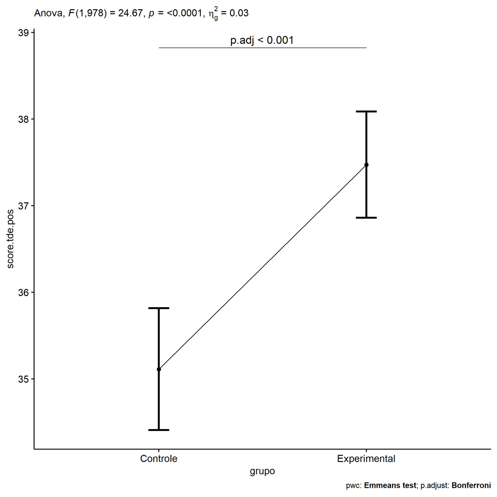

```r
if (!is.null(nrow(plots[["grupo"]]$data)))
  plots[["grupo"]] +
  if (ymin.ci < ymax.ci) ggplot2::ylim(ymin.ci, ymax.ci)
```

```r
plots <- oneWayAncovaBoxPlots(
  wdat, "score.tde.pos", "grupo", aov, pwc, covar = "score.tde.pre",
  theme = "classic", color = color[["grupo"]],
  subtitle = which(aov$Effect == "grupo"))
```

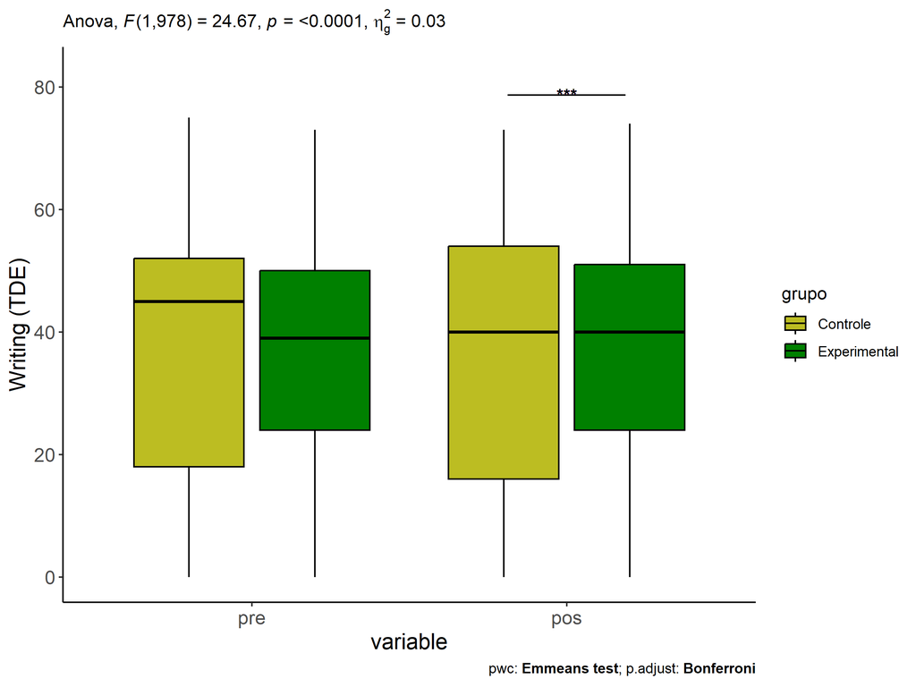

```r
if (length(unique(wdat[["grupo"]])) > 1)
  plots[["grupo"]] + ggplot2::ylab("Writing (TDE)") +
  ggplot2::scale_x_discrete(labels=c('pre', 'pos')) +
  if (ymin < ymax) ggplot2::ylim(ymin, ymax)
```

```r
if (length(unique(wdat.long[["grupo"]])) > 1)
  plots <- oneWayAncovaBoxPlots(
    wdat.long, "score.tde", "grupo", aov, pwc.long,
    pre.post = "time", theme = "classic", color = color$prepost)
```

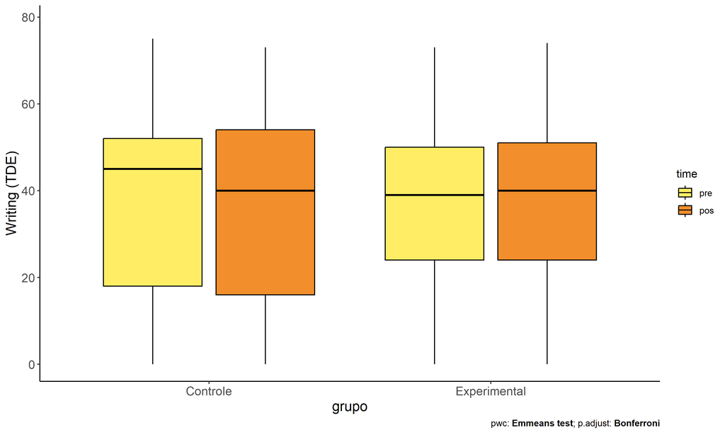

```r
if (length(unique(wdat.long[["grupo"]])) > 1)
  plots[["grupo"]] + ggplot2::ylab("Writing (TDE)") +
  if (ymin < ymax) ggplot2::ylim(ymin, ymax)
```

### Checking linearity assumption

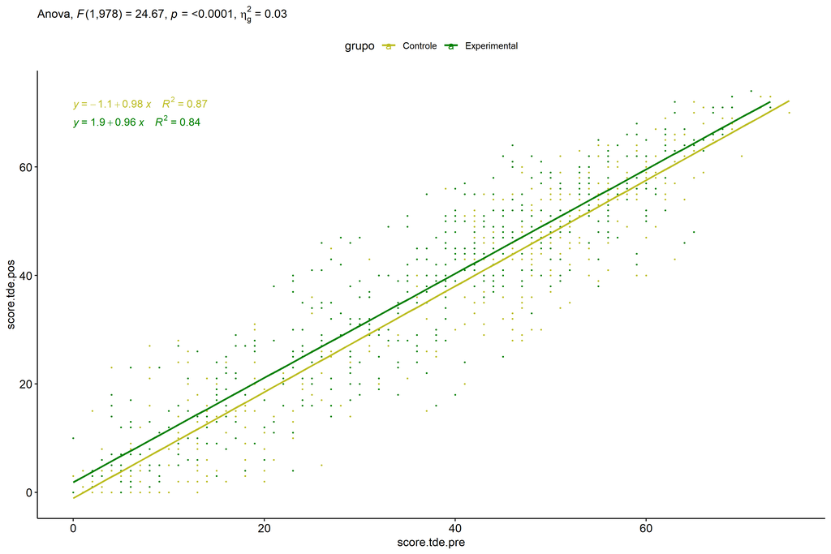

```r
ggscatter(wdat, x = "score.tde.pre", y = "score.tde.pos", size = 0.5,
          color = "grupo", add = "reg.line")+
  stat_regline_equation(
    aes(label =  paste(..eq.label.., ..rr.label.., sep = "~~~~"), color = grupo)
  ) +
  ggplot2::labs(subtitle = rstatix::get_test_label(aov, detailed = T, row = which(aov$Effect == "grupo"))) +
  ggplot2::scale_color_manual(values = color[["grupo"]]) +
  if (ymin < ymax) ggplot2::ylim(ymin, ymax)
```

### Checking normality and homogeneity

```r
res <- augment(lm(score.tde.pos ~ score.tde.pre + grupo, data = wdat))
```

```r
shapiro_test(res$.resid)
```

```
## # A tibble: 1 × 3
##   variable   statistic p.value
##   <chr>          <dbl>   <dbl>
## 1 res$.resid     0.996  0.0185
```

```r
levene_test(res, .resid ~ grupo)
```

```
## # A tibble: 1 × 4
##     df1   df2 statistic     p
##   <int> <int>     <dbl> <dbl>
## 1     1   979   0.00118 0.973
```

# ANCOVA and Pairwise for two factors **grupo:Sexo**

## Without remove non-normal data

```r
pdat = remove_group_data(dat[!is.na(dat[["grupo"]]) & !is.na(dat[["Sexo"]]),],
                         "score.tde.pos", c("grupo","Sexo"))
pdat = pdat[pdat[["Sexo"]] %in% do.call(
  intersect, lapply(unique(pdat[["grupo"]]), FUN = function(x) {
    unique(pdat[["Sexo"]][which(pdat[["grupo"]] == x)])
  })),]
pdat[["grupo"]] = factor(pdat[["grupo"]], level[["grupo"]])
pdat[["Sexo"]] = factor(
  pdat[["Sexo"]],
  level[["Sexo"]][level[["Sexo"]] %in% unique(pdat[["Sexo"]])])

pdat.long <- rbind(pdat[,c("id","grupo","Sexo")], pdat[,c("id","grupo","Sexo")])
pdat.long[["time"]] <- c(rep("pre", nrow(pdat)), rep("pos", nrow(pdat)))
pdat.long[["time"]] <- factor(pdat.long[["time"]], c("pre","pos"))
pdat.long[["score.tde"]] <- c(pdat[["score.tde.pre"]], pdat[["score.tde.pos"]])

if (length(unique(pdat[["Sexo"]])) >= 2) {
  aov = anova_test(pdat, score.tde.pos ~ score.tde.pre + grupo*Sexo)
  laov[["grupo:Sexo"]] <- get_anova_table(aov)
}
```

```r
if (length(unique(pdat[["Sexo"]])) >= 2) {
  pwcs <- list()
  pwcs[["Sexo"]] <- emmeans_test(
    group_by(pdat, grupo), score.tde.pos ~ Sexo,
    covariate = score.tde.pre, p.adjust.method = "bonferroni")
  pwcs[["grupo"]] <- emmeans_test(
    group_by(pdat, Sexo), score.tde.pos ~ grupo,
    covariate = score.tde.pre, p.adjust.method = "bonferroni")

  pwc <- plyr::rbind.fill(pwcs[["grupo"]], pwcs[["Sexo"]])
  pwc <- pwc[,c("grupo","Sexo", colnames(pwc)[!colnames(pwc) %in% c("grupo","Sexo")])]
}
```

```r
if (length(unique(pdat[["Sexo"]])) >= 2) {
  pwc.long <- emmeans_test(dplyr::group_by_at(pdat.long, c("grupo","Sexo")),
                           score.tde ~ time,
                           p.adjust.method = "bonferroni")
  lpwc[["grupo:Sexo"]] <- plyr::rbind.fill(pwc, pwc.long)
}
```

```r
if (length(unique(pdat[["Sexo"]])) >= 2) {
  ds <- get.descriptives(pdat, "score.tde.pos", c("grupo","Sexo"), covar = "score.tde.pre")
  ds <- merge(ds[ds$variable != "score.tde.pre",],
              ds[ds$variable == "score.tde.pre", !colnames(ds) %in% c("variable")],
              by = c("grupo","Sexo"), all.x = T, suffixes = c("", ".score.tde.pre"))
  ds <- merge(get_emmeans(pwcs[["grupo"]]), ds,
              by = c("grupo","Sexo"), suffixes = c(".emms", ""))
  ds <- ds[,c("grupo","Sexo","n","mean.score.tde.pre","se.score.tde.pre","mean","se",
              "emmean","se.emms","conf.low","conf.high")]

  colnames(ds) <- c("grupo","Sexo", "N", paste0(c("M","SE")," (pre)"),
                    paste0(c("M","SE"), " (unadj)"),
                    paste0(c("M", "SE"), " (adj)"), "conf.low", "conf.high")

  lemms[["grupo:Sexo"]] <- ds
}
```

## Computing ANCOVA and PairWise After removing non-normal data (OK)

```r
if (length(unique(pdat[["Sexo"]])) >= 2) {
  wdat = pdat

  res = residuals(lm(score.tde.pos ~ score.tde.pre + grupo*Sexo, data = wdat))
  non.normal = getNonNormal(res, wdat$id, plimit = 0.05)

  wdat = wdat[!wdat$id %in% non.normal,]

  wdat.long <- rbind(wdat[,c("id","grupo","Sexo")], wdat[,c("id","grupo","Sexo")])
  wdat.long[["time"]] <- c(rep("pre", nrow(wdat)), rep("pos", nrow(wdat)))
  wdat.long[["time"]] <- factor(wdat.long[["time"]], c("pre","pos"))
  wdat.long[["score.tde"]] <- c(wdat[["score.tde.pre"]], wdat[["score.tde.pos"]])


  ldat[["grupo:Sexo"]] = wdat

  (non.normal)
}
```

```
##   [1] "P962"  "P1128" "P984"  "P1129" "P3637" "P1126" "P1971" "P2995" "P2871" "P572"  "P921"
##  [12] "P3019" "P2994" "P2880" "P2848" "P2983" "P908"  "P3021" "P3054" "P1139" "P2858" "P2835"
##  [23] "P2904" "P1117" "P3015" "P2870" "P2929" "P2910" "P2886" "P914"  "P2913" "P1111" "P2974"
##  [34] "P2964" "P2867" "P2876" "P2937" "P1840" "P2973" "P3007" "P2861" "P2969" "P2953" "P2986"
##  [45] "P2883" "P2831" "P2975" "P1018" "P3476" "P2997" "P3005" "P1878" "P2866" "P2950" "P2993"
##  [56] "P3545" "P2917" "P2978" "P3029" "P2864" "P2888" "P976"  "P2854" "P2959" "P3548" "P2190"
##  [67] "P929"  "P3574" "P2947" "P2845" "P1983" "P3674" "P1149" "P1068" "P3475" "P2004" "P2860"
##  [78] "P2982" "P2839" "P3024" "P1885" "P2868" "P609"  "P2990" "P2946" "P1056" "P2933" "P3020"
##  [89] "P2879" "P873"  "P1887" "P2865" "P3026" "P3660" "P2956" "P3080" "P3666" "P2846" "P3533"
## [100] "P3228" "P2948" "P2850" "P3000" "P809"  "P2905" "P1046" "P1118" "P3221" "P1665" "P2903"
## [111] "P1597" "P2836" "P3537" "P584"  "P854"  "P1127" "P1804" "P2869" "P2979" "P3571" "P1652"
## [122] "P924"  "P1803" "P3088" "P1592" "P2901" "P3608" "P848"  "P1964" "P2971" "P1900" "P996"
## [133] "P3732" "P492"  "P2922" "P859"  "P2980" "P1916" "P2832" "P1858" "P1151" "P2375" "P3156"
## [144] "P3030" "P3061" "P2327" "P2894"
```

```r
if (length(unique(pdat[["Sexo"]])) >= 2) {
  aov = anova_test(wdat, score.tde.pos ~ score.tde.pre + grupo*Sexo)
  laov[["grupo:Sexo"]] <- merge(get_anova_table(aov), laov[["grupo:Sexo"]],
                                         by="Effect", suffixes = c("","'"))
  df = get_anova_table(aov)
}
```

| Effect | DFn | DFd | F | p | p<.05 | ges |
| --- | --- | --- | --- | --- | --- | --- |
| score.tde.pre | 1 | 969 | 5974.401 | 0.000 | * | 0.860 |
| grupo | 1 | 969 | 23.992 | 0.000 | * | 0.024 |
| Sexo | 1 | 969 | 0.058 | 0.810 |  | 0.000 |
| grupo:Sexo | 1 | 969 | 0.548 | 0.459 |  | 0.001 |

```r
if (length(unique(pdat[["Sexo"]])) >= 2) {
  pwcs <- list()
  pwcs[["Sexo"]] <- emmeans_test(
    group_by(wdat, grupo), score.tde.pos ~ Sexo,
    covariate = score.tde.pre, p.adjust.method = "bonferroni")
  pwcs[["grupo"]] <- emmeans_test(
    group_by(wdat, Sexo), score.tde.pos ~ grupo,
    covariate = score.tde.pre, p.adjust.method = "bonferroni")

  pwc <- plyr::rbind.fill(pwcs[["grupo"]], pwcs[["Sexo"]])
  pwc <- pwc[,c("grupo","Sexo", colnames(pwc)[!colnames(pwc) %in% c("grupo","Sexo")])]
}
```

| grupo | Sexo | term | .y. | group1 | group2 | df | statistic | p | p.adj | p.adj.signif |
| --- | --- | --- | --- | --- | --- | --- | --- | --- | --- | --- |
|  | F | score.tde.pre*grupo | score.tde.pos | Controle | Experimental | 969 | -3.977 | 0.000 | 0.000 | **** |
|  | M | score.tde.pre*grupo | score.tde.pos | Controle | Experimental | 969 | -2.953 | 0.003 | 0.003 | ** |
| Controle |  | score.tde.pre*Sexo | score.tde.pos | F | M | 969 | -0.398 | 0.691 | 0.691 | ns |
| Experimental |  | score.tde.pre*Sexo | score.tde.pos | F | M | 969 | 0.663 | 0.507 | 0.507 | ns |

```r
if (length(unique(pdat[["Sexo"]])) >= 2) {
  pwc.long <- emmeans_test(dplyr::group_by_at(wdat.long, c("grupo","Sexo")),
                           score.tde ~ time,
                           p.adjust.method = "bonferroni")
  lpwc[["grupo:Sexo"]] <- merge(plyr::rbind.fill(pwc, pwc.long),
                                         lpwc[["grupo:Sexo"]],
                                         by=c("grupo","Sexo","term",".y.","group1","group2"),
                                         suffixes = c("","'"))
}
```

| grupo | Sexo | term | .y. | group1 | group2 | df | statistic | p | p.adj | p.adj.signif |
| --- | --- | --- | --- | --- | --- | --- | --- | --- | --- | --- |
| Controle | F | time | score.tde | pre | pos | 1940 | 1.089 | 0.276 | 0.276 | ns |
| Controle | M | time | score.tde | pre | pos | 1940 | 0.837 | 0.403 | 0.403 | ns |
| Experimental | F | time | score.tde | pre | pos | 1940 | -0.403 | 0.687 | 0.687 | ns |
| Experimental | M | time | score.tde | pre | pos | 1940 | -0.251 | 0.802 | 0.802 | ns |

```r
if (length(unique(pdat[["Sexo"]])) >= 2) {
  ds <- get.descriptives(wdat, "score.tde.pos", c("grupo","Sexo"), covar = "score.tde.pre")
  ds <- merge(ds[ds$variable != "score.tde.pre",],
              ds[ds$variable == "score.tde.pre", !colnames(ds) %in% c("variable")],
              by = c("grupo","Sexo"), all.x = T, suffixes = c("", ".score.tde.pre"))
  ds <- merge(get_emmeans(pwcs[["grupo"]]), ds,
              by = c("grupo","Sexo"), suffixes = c(".emms", ""))
  ds <- ds[,c("grupo","Sexo","n","mean.score.tde.pre","se.score.tde.pre",
              "mean","se","emmean","se.emms","conf.low","conf.high")]

  colnames(ds) <- c("grupo","Sexo", "N", paste0(c("M","SE")," (pre)"),
                    paste0(c("M","SE"), " (unadj)"),
                    paste0(c("M", "SE"), " (adj)"), "conf.low", "conf.high")

  lemms[["grupo:Sexo"]] <- merge(ds, lemms[["grupo:Sexo"]],
                                          by=c("grupo","Sexo"), suffixes = c("","'"))
}
```

| grupo | Sexo | N | M (pre) | SE (pre) | M (unadj) | SE (unadj) | M (adj) | SE (adj) | conf.low | conf.high |
| --- | --- | --- | --- | --- | --- | --- | --- | --- | --- | --- |
| Controle | F | 208 | 40.635 | 1.278 | 38.615 | 1.351 | 35.106 | 0.503 | 34.119 | 36.093 |
| Controle | M | 211 | 33.934 | 1.457 | 32.393 | 1.517 | 35.389 | 0.499 | 34.410 | 36.368 |
| Experimental | F | 276 | 39.623 | 1.053 | 40.272 | 1.123 | 37.744 | 0.436 | 36.889 | 38.600 |
| Experimental | M | 279 | 34.082 | 1.030 | 34.484 | 1.053 | 37.335 | 0.434 | 36.483 | 38.187 |

### Plots for ancova

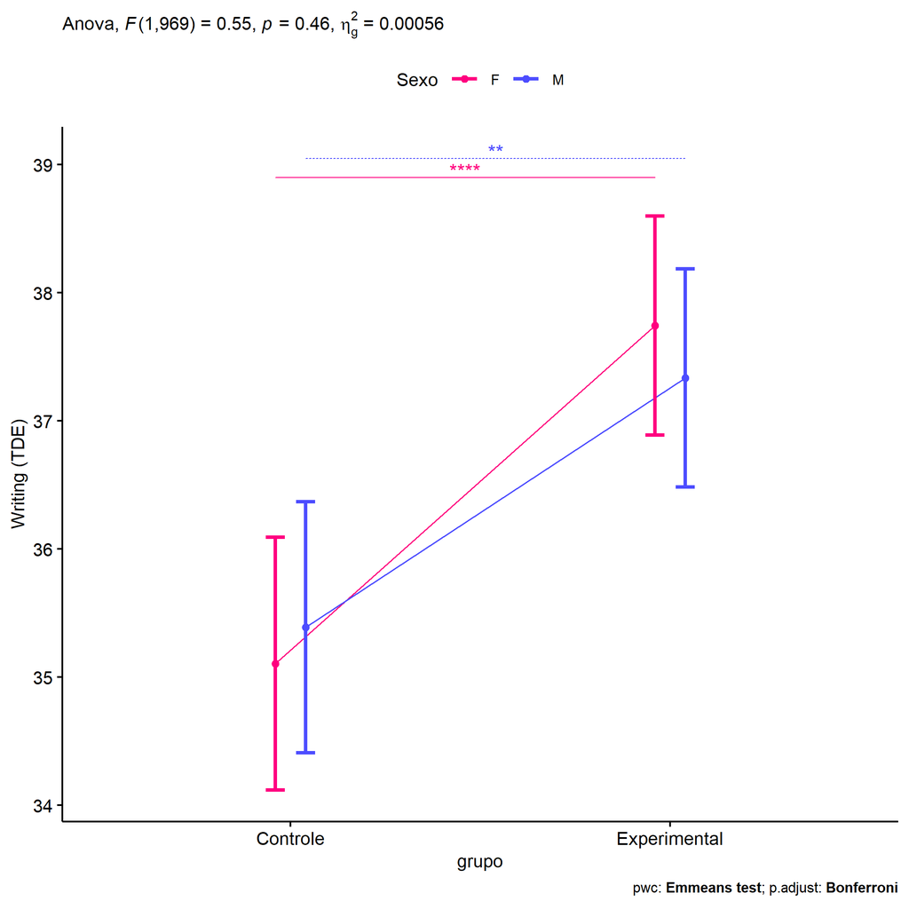

```r
if (length(unique(pdat[["Sexo"]])) >= 2) {
  ggPlotAoC2(pwcs, "grupo", "Sexo", aov, ylab = "Writing (TDE)",
             subtitle = which(aov$Effect == "grupo:Sexo"), addParam = "errorbar") +
    ggplot2::scale_color_manual(values = color[["Sexo"]]) +
    if (ymin.ci < ymax.ci) ggplot2::ylim(ymin.ci, ymax.ci)
}
```

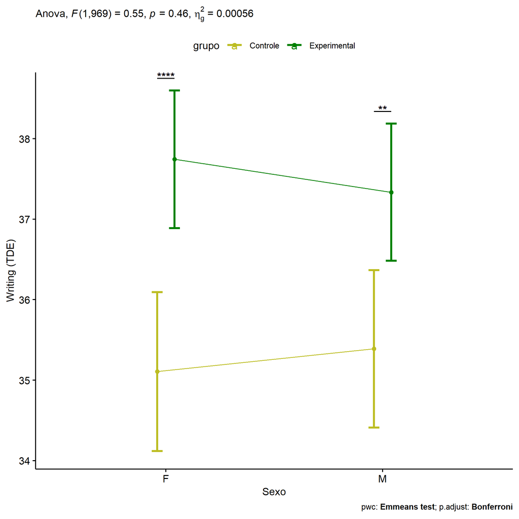

```r
if (length(unique(pdat[["Sexo"]])) >= 2) {
  ggPlotAoC2(pwcs, "Sexo", "grupo", aov, ylab = "Writing (TDE)",
               subtitle = which(aov$Effect == "grupo:Sexo"), addParam = "errorbar") +
      ggplot2::scale_color_manual(values = color[["grupo"]]) +
      if (ymin.ci < ymax.ci) ggplot2::ylim(ymin.ci, ymax.ci)
}
```

```r
if (length(unique(pdat[["Sexo"]])) >= 2) {
  plots <- twoWayAncovaBoxPlots(
    wdat, "score.tde.pos", c("grupo","Sexo"), aov, pwcs, covar = "score.tde.pre",
    theme = "classic", color = color[["grupo:Sexo"]],
    subtitle = which(aov$Effect == "grupo:Sexo"))
}
```

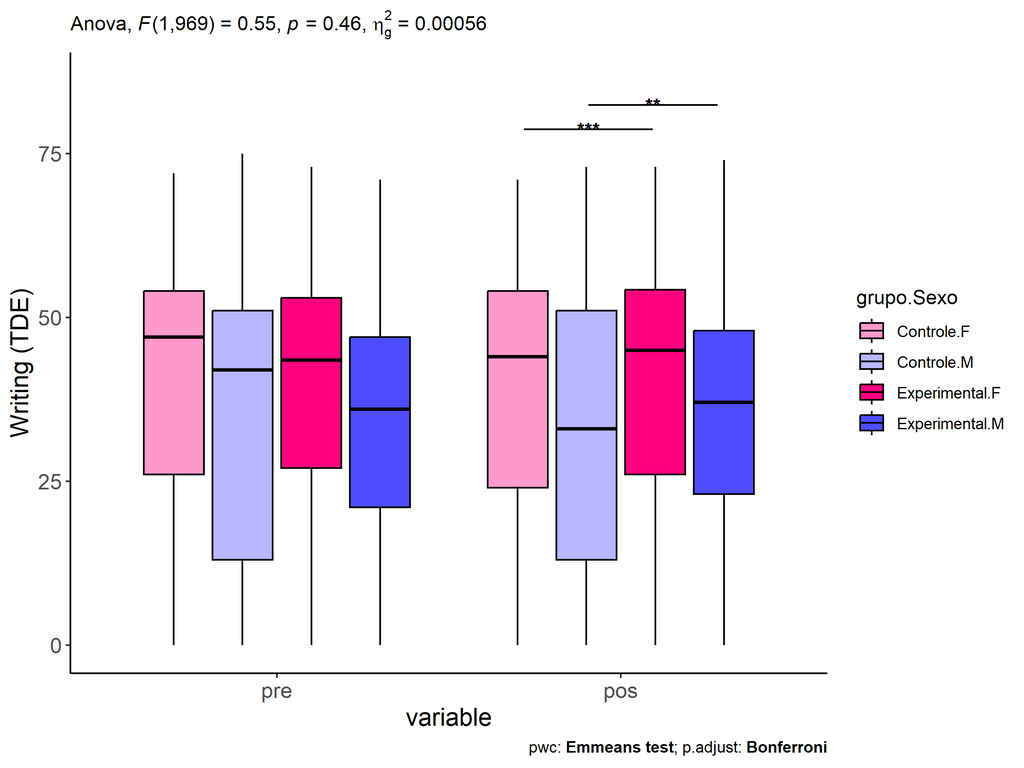

```r
if (length(unique(pdat[["Sexo"]])) >= 2) {
  plots[["grupo:Sexo"]] + ggplot2::ylab("Writing (TDE)") +
  ggplot2::scale_x_discrete(labels=c('pre', 'pos')) +
  if (ymin < ymax) ggplot2::ylim(ymin, ymax)
}
```

```r
if (length(unique(pdat[["Sexo"]])) >= 2) {
  plots <- twoWayAncovaBoxPlots(
    wdat.long, "score.tde", c("grupo","Sexo"), aov, pwc.long,
    pre.post = "time",
    theme = "classic", color = color$prepost)
}
```

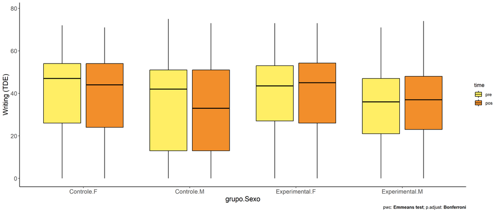

```r
if (length(unique(pdat[["Sexo"]])) >= 2)
  plots[["grupo:Sexo"]] + ggplot2::ylab("Writing (TDE)") +
    if (ymin < ymax) ggplot2::ylim(ymin, ymax)
```

### Checking linearity assumption

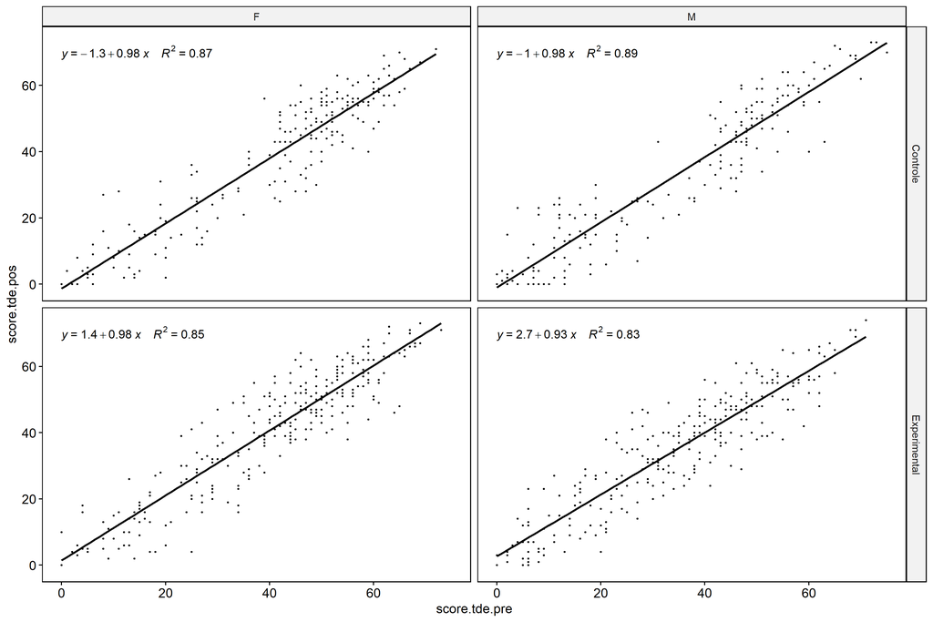

```r
if (length(unique(pdat[["Sexo"]])) >= 2) {
  ggscatter(wdat, x = "score.tde.pre", y = "score.tde.pos", size = 0.5,
            facet.by = c("grupo","Sexo"), add = "reg.line")+
    stat_regline_equation(
      aes(label =  paste(..eq.label.., ..rr.label.., sep = "~~~~"))
    ) +
    if (ymin < ymax) ggplot2::ylim(ymin, ymax)
}
```

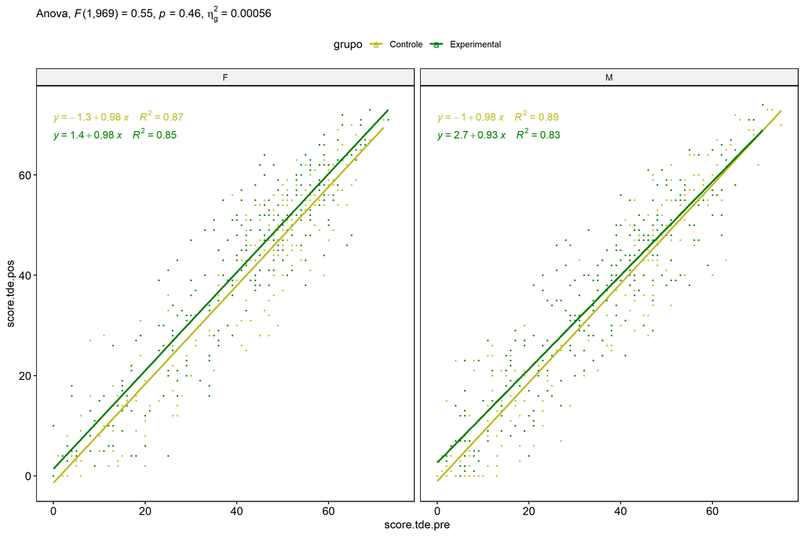

```r
if (length(unique(pdat[["Sexo"]])) >= 2) {
  ggscatter(wdat, x = "score.tde.pre", y = "score.tde.pos", size = 0.5,
            color = "grupo", facet.by = "Sexo", add = "reg.line")+
    stat_regline_equation(
      aes(label =  paste(..eq.label.., ..rr.label.., sep = "~~~~"), color = grupo)
    ) +
    ggplot2::labs(subtitle = rstatix::get_test_label(aov, detailed = T, row = which(aov$Effect == "grupo:Sexo"))) +
    ggplot2::scale_color_manual(values = color[["grupo"]]) +
    if (ymin < ymax) ggplot2::ylim(ymin, ymax)
}
```

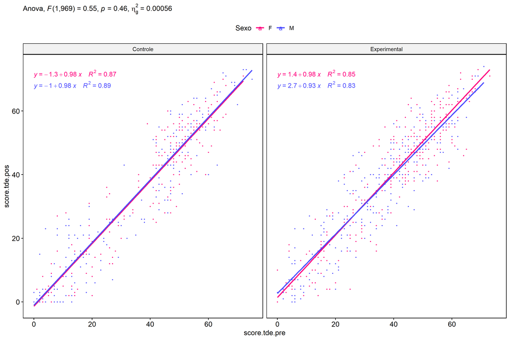

```r
if (length(unique(pdat[["Sexo"]])) >= 2) {
  ggscatter(wdat, x = "score.tde.pre", y = "score.tde.pos", size = 0.5,
            color = "Sexo", facet.by = "grupo", add = "reg.line")+
    stat_regline_equation(
      aes(label =  paste(..eq.label.., ..rr.label.., sep = "~~~~"), color = Sexo)
    ) +
    ggplot2::labs(subtitle = rstatix::get_test_label(aov, detailed = T, row = which(aov$Effect == "grupo:Sexo"))) +
    ggplot2::scale_color_manual(values = color[["Sexo"]]) +
    if (ymin < ymax) ggplot2::ylim(ymin, ymax)
}
```

### Checking normality and homogeneity

```r
if (length(unique(pdat[["Sexo"]])) >= 2)
  res <- augment(lm(score.tde.pos ~ score.tde.pre + grupo*Sexo, data = wdat))
```

```r
if (length(unique(pdat[["Sexo"]])) >= 2)
  shapiro_test(res$.resid)
```

```
## # A tibble: 1 × 3
##   variable   statistic p.value
##   <chr>          <dbl>   <dbl>
## 1 res$.resid     0.997  0.0375
```

```r
if (length(unique(pdat[["Sexo"]])) >= 2)
  levene_test(res, .resid ~ grupo*Sexo)
```

```
## # A tibble: 1 × 4
##     df1   df2 statistic     p
##   <int> <int>     <dbl> <dbl>
## 1     3   970    0.0813 0.970
```

# ANCOVA and Pairwise for two factors **grupo:Zona**

## Without remove non-normal data

```r
pdat = remove_group_data(dat[!is.na(dat[["grupo"]]) & !is.na(dat[["Zona"]]),],
                         "score.tde.pos", c("grupo","Zona"))
pdat = pdat[pdat[["Zona"]] %in% do.call(
  intersect, lapply(unique(pdat[["grupo"]]), FUN = function(x) {
    unique(pdat[["Zona"]][which(pdat[["grupo"]] == x)])
  })),]
pdat[["grupo"]] = factor(pdat[["grupo"]], level[["grupo"]])
pdat[["Zona"]] = factor(
  pdat[["Zona"]],
  level[["Zona"]][level[["Zona"]] %in% unique(pdat[["Zona"]])])

pdat.long <- rbind(pdat[,c("id","grupo","Zona")], pdat[,c("id","grupo","Zona")])
pdat.long[["time"]] <- c(rep("pre", nrow(pdat)), rep("pos", nrow(pdat)))
pdat.long[["time"]] <- factor(pdat.long[["time"]], c("pre","pos"))
pdat.long[["score.tde"]] <- c(pdat[["score.tde.pre"]], pdat[["score.tde.pos"]])

if (length(unique(pdat[["Zona"]])) >= 2) {
  aov = anova_test(pdat, score.tde.pos ~ score.tde.pre + grupo*Zona)
  laov[["grupo:Zona"]] <- get_anova_table(aov)
}
```

```r
if (length(unique(pdat[["Zona"]])) >= 2) {
  pwcs <- list()
  pwcs[["Zona"]] <- emmeans_test(
    group_by(pdat, grupo), score.tde.pos ~ Zona,
    covariate = score.tde.pre, p.adjust.method = "bonferroni")
  pwcs[["grupo"]] <- emmeans_test(
    group_by(pdat, Zona), score.tde.pos ~ grupo,
    covariate = score.tde.pre, p.adjust.method = "bonferroni")

  pwc <- plyr::rbind.fill(pwcs[["grupo"]], pwcs[["Zona"]])
  pwc <- pwc[,c("grupo","Zona", colnames(pwc)[!colnames(pwc) %in% c("grupo","Zona")])]
}
```

```r
if (length(unique(pdat[["Zona"]])) >= 2) {
  pwc.long <- emmeans_test(dplyr::group_by_at(pdat.long, c("grupo","Zona")),
                           score.tde ~ time,
                           p.adjust.method = "bonferroni")
  lpwc[["grupo:Zona"]] <- plyr::rbind.fill(pwc, pwc.long)
}
```

```r
if (length(unique(pdat[["Zona"]])) >= 2) {
  ds <- get.descriptives(pdat, "score.tde.pos", c("grupo","Zona"), covar = "score.tde.pre")
  ds <- merge(ds[ds$variable != "score.tde.pre",],
              ds[ds$variable == "score.tde.pre", !colnames(ds) %in% c("variable")],
              by = c("grupo","Zona"), all.x = T, suffixes = c("", ".score.tde.pre"))
  ds <- merge(get_emmeans(pwcs[["grupo"]]), ds,
              by = c("grupo","Zona"), suffixes = c(".emms", ""))
  ds <- ds[,c("grupo","Zona","n","mean.score.tde.pre","se.score.tde.pre","mean","se",
              "emmean","se.emms","conf.low","conf.high")]

  colnames(ds) <- c("grupo","Zona", "N", paste0(c("M","SE")," (pre)"),
                    paste0(c("M","SE"), " (unadj)"),
                    paste0(c("M", "SE"), " (adj)"), "conf.low", "conf.high")

  lemms[["grupo:Zona"]] <- ds
}
```

## Computing ANCOVA and PairWise After removing non-normal data (OK)

```r
if (length(unique(pdat[["Zona"]])) >= 2) {
  wdat = pdat

  res = residuals(lm(score.tde.pos ~ score.tde.pre + grupo*Zona, data = wdat))
  non.normal = getNonNormal(res, wdat$id, plimit = 0.05)

  wdat = wdat[!wdat$id %in% non.normal,]

  wdat.long <- rbind(wdat[,c("id","grupo","Zona")], wdat[,c("id","grupo","Zona")])
  wdat.long[["time"]] <- c(rep("pre", nrow(wdat)), rep("pos", nrow(wdat)))
  wdat.long[["time"]] <- factor(wdat.long[["time"]], c("pre","pos"))
  wdat.long[["score.tde"]] <- c(wdat[["score.tde.pre"]], wdat[["score.tde.pos"]])


  ldat[["grupo:Zona"]] = wdat

  (non.normal)
}
```

```
##  [1] "P962"  "P984"  "P1971" "P2929" "P1117" "P2848" "P2917" "P2870" "P2871" "P2835" "P921"
## [12] "P2959" "P3029" "P1139" "P572"  "P2983" "P2858" "P3021" "P3080" "P606"  "P2933" "P914"
## [23] "P2831" "P2946" "P3533" "P2953" "P2886" "P3548" "P3476" "P2861" "P2880" "P2982" "P2995"
## [34] "P3674" "P2864" "P2883" "P2950" "P2004" "P3475" "P3012" "P3010" "P3015" "P2975" "P2937"
## [45] "P3660" "P2910" "P1691" "P2868" "P2860" "P1878" "P609"  "P908"  "P2997" "P2956" "P2973"
## [56] "P2879" "P2854" "P3024" "P2967" "P2948" "P2909" "P1056" "P2964"
```

```r
if (length(unique(pdat[["Zona"]])) >= 2) {
  aov = anova_test(wdat, score.tde.pos ~ score.tde.pre + grupo*Zona)
  laov[["grupo:Zona"]] <- merge(get_anova_table(aov), laov[["grupo:Zona"]],
                                         by="Effect", suffixes = c("","'"))
  df = get_anova_table(aov)
}
```

| Effect | DFn | DFd | F | p | p<.05 | ges |
| --- | --- | --- | --- | --- | --- | --- |
| score.tde.pre | 1 | 735 | 3559.226 | 0 | * | 0.829 |
| grupo | 1 | 735 | 26.138 | 0 | * | 0.034 |
| Zona | 1 | 735 | 54.679 | 0 | * | 0.069 |
| grupo:Zona | 1 | 735 | 14.155 | 0 | * | 0.019 |

```r
if (length(unique(pdat[["Zona"]])) >= 2) {
  pwcs <- list()
  pwcs[["Zona"]] <- emmeans_test(
    group_by(wdat, grupo), score.tde.pos ~ Zona,
    covariate = score.tde.pre, p.adjust.method = "bonferroni")
  pwcs[["grupo"]] <- emmeans_test(
    group_by(wdat, Zona), score.tde.pos ~ grupo,
    covariate = score.tde.pre, p.adjust.method = "bonferroni")

  pwc <- plyr::rbind.fill(pwcs[["grupo"]], pwcs[["Zona"]])
  pwc <- pwc[,c("grupo","Zona", colnames(pwc)[!colnames(pwc) %in% c("grupo","Zona")])]
}
```

| grupo | Zona | term | .y. | group1 | group2 | df | statistic | p | p.adj | p.adj.signif |
| --- | --- | --- | --- | --- | --- | --- | --- | --- | --- | --- |
|  | Rural | score.tde.pre*grupo | score.tde.pos | Controle | Experimental | 735 | -2.009 | 0.045 | 0.045 | * |
|  | Urbana | score.tde.pre*grupo | score.tde.pos | Controle | Experimental | 735 | -6.023 | 0.000 | 0.000 | **** |
| Controle |  | score.tde.pre*Zona | score.tde.pos | Rural | Urbana | 735 | 7.675 | 0.000 | 0.000 | **** |
| Experimental |  | score.tde.pre*Zona | score.tde.pos | Rural | Urbana | 735 | 3.188 | 0.001 | 0.001 | ** |

```r
if (length(unique(pdat[["Zona"]])) >= 2) {
  pwc.long <- emmeans_test(dplyr::group_by_at(wdat.long, c("grupo","Zona")),
                           score.tde ~ time,
                           p.adjust.method = "bonferroni")
  lpwc[["grupo:Zona"]] <- merge(plyr::rbind.fill(pwc, pwc.long),
                                         lpwc[["grupo:Zona"]],
                                         by=c("grupo","Zona","term",".y.","group1","group2"),
                                         suffixes = c("","'"))
}
```

| grupo | Zona | term | .y. | group1 | group2 | df | statistic | p | p.adj | p.adj.signif |
| --- | --- | --- | --- | --- | --- | --- | --- | --- | --- | --- |
| Controle | Rural | time | score.tde | pre | pos | 1472 | 0.543 | 0.588 | 0.588 | ns |
| Controle | Urbana | time | score.tde | pre | pos | 1472 | 3.191 | 0.001 | 0.001 | ** |
| Experimental | Rural | time | score.tde | pre | pos | 1472 | -0.333 | 0.739 | 0.739 | ns |
| Experimental | Urbana | time | score.tde | pre | pos | 1472 | 1.001 | 0.317 | 0.317 | ns |

```r
if (length(unique(pdat[["Zona"]])) >= 2) {
  ds <- get.descriptives(wdat, "score.tde.pos", c("grupo","Zona"), covar = "score.tde.pre")
  ds <- merge(ds[ds$variable != "score.tde.pre",],
              ds[ds$variable == "score.tde.pre", !colnames(ds) %in% c("variable")],
              by = c("grupo","Zona"), all.x = T, suffixes = c("", ".score.tde.pre"))
  ds <- merge(get_emmeans(pwcs[["grupo"]]), ds,
              by = c("grupo","Zona"), suffixes = c(".emms", ""))
  ds <- ds[,c("grupo","Zona","n","mean.score.tde.pre","se.score.tde.pre",
              "mean","se","emmean","se.emms","conf.low","conf.high")]

  colnames(ds) <- c("grupo","Zona", "N", paste0(c("M","SE")," (pre)"),
                    paste0(c("M","SE"), " (unadj)"),
                    paste0(c("M", "SE"), " (adj)"), "conf.low", "conf.high")

  lemms[["grupo:Zona"]] <- merge(ds, lemms[["grupo:Zona"]],
                                          by=c("grupo","Zona"), suffixes = c("","'"))
}
```

| grupo | Zona | N | M (pre) | SE (pre) | M (unadj) | SE (unadj) | M (adj) | SE (adj) | conf.low | conf.high |
| --- | --- | --- | --- | --- | --- | --- | --- | --- | --- | --- |
| Controle | Rural | 228 | 35.956 | 1.330 | 34.978 | 1.426 | 35.358 | 0.547 | 34.284 | 36.432 |
| Controle | Urbana | 101 | 39.743 | 1.823 | 31.099 | 2.044 | 27.763 | 0.824 | 26.145 | 29.380 |
| Experimental | Rural | 260 | 34.215 | 1.113 | 34.777 | 1.186 | 36.865 | 0.514 | 35.857 | 37.874 |
| Experimental | Urbana | 151 | 38.318 | 1.389 | 36.099 | 1.501 | 34.161 | 0.673 | 32.840 | 35.483 |

### Plots for ancova

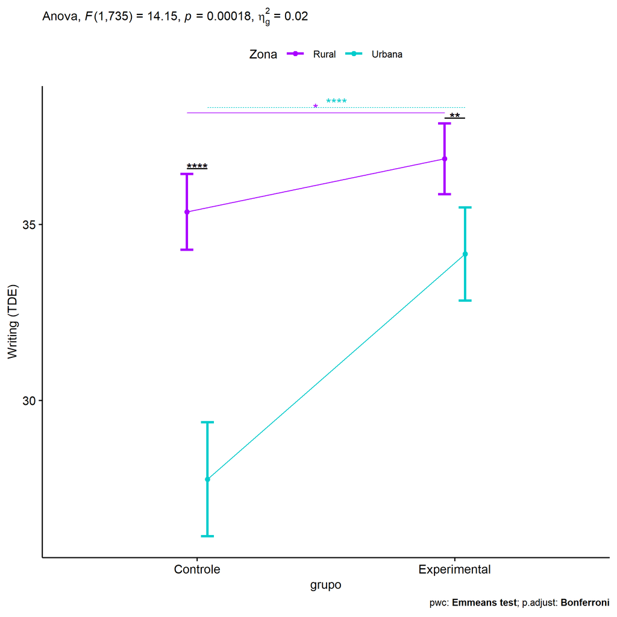

```r
if (length(unique(pdat[["Zona"]])) >= 2) {
  ggPlotAoC2(pwcs, "grupo", "Zona", aov, ylab = "Writing (TDE)",
             subtitle = which(aov$Effect == "grupo:Zona"), addParam = "errorbar") +
    ggplot2::scale_color_manual(values = color[["Zona"]]) +
    if (ymin.ci < ymax.ci) ggplot2::ylim(ymin.ci, ymax.ci)
}
```

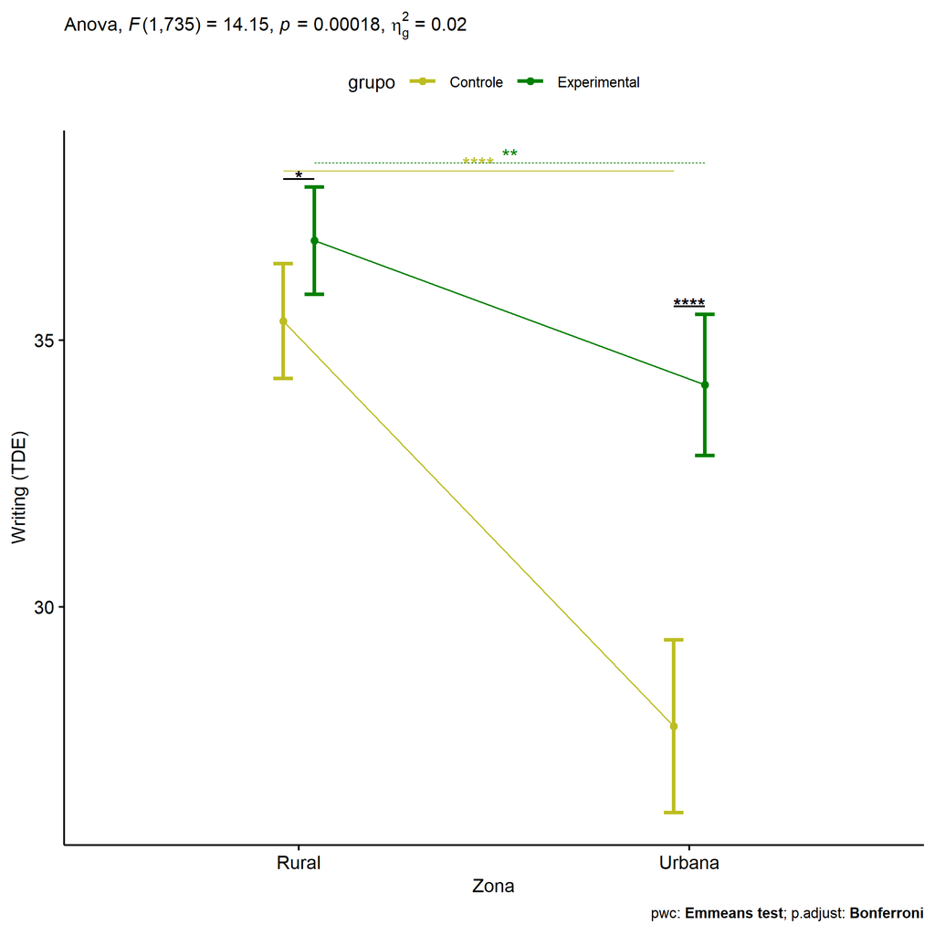

```r
if (length(unique(pdat[["Zona"]])) >= 2) {
  ggPlotAoC2(pwcs, "Zona", "grupo", aov, ylab = "Writing (TDE)",
               subtitle = which(aov$Effect == "grupo:Zona"), addParam = "errorbar") +
      ggplot2::scale_color_manual(values = color[["grupo"]]) +
      if (ymin.ci < ymax.ci) ggplot2::ylim(ymin.ci, ymax.ci)
}
```

```r
if (length(unique(pdat[["Zona"]])) >= 2) {
  plots <- twoWayAncovaBoxPlots(
    wdat, "score.tde.pos", c("grupo","Zona"), aov, pwcs, covar = "score.tde.pre",
    theme = "classic", color = color[["grupo:Zona"]],
    subtitle = which(aov$Effect == "grupo:Zona"))
}
```

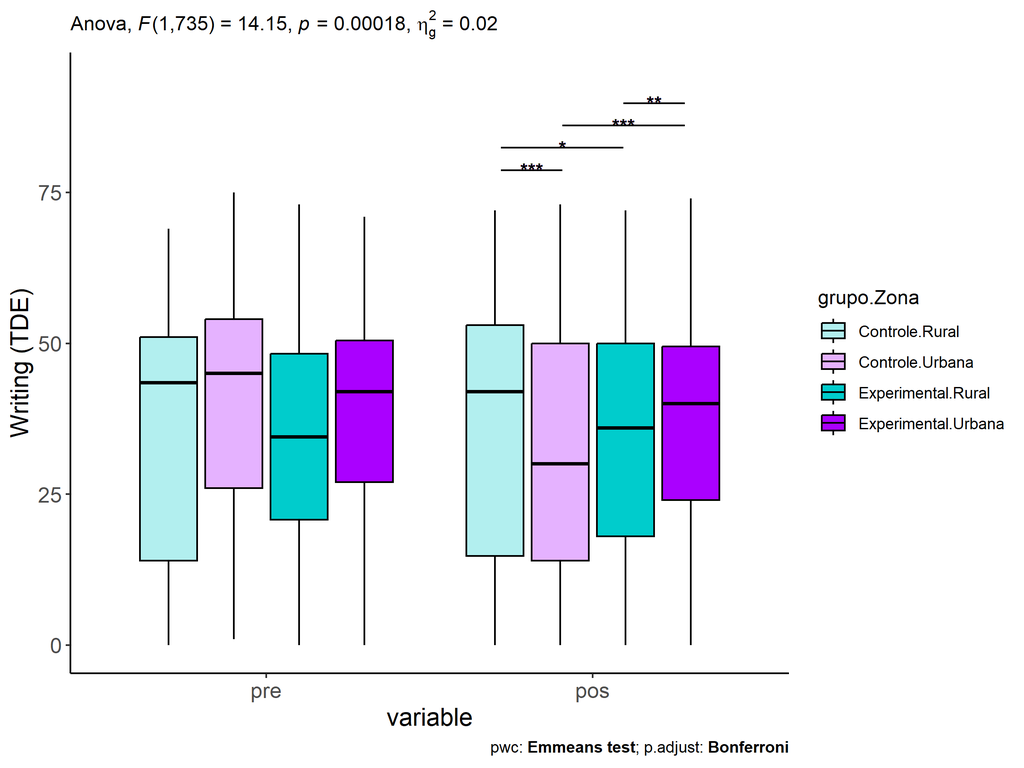

```r
if (length(unique(pdat[["Zona"]])) >= 2) {
  plots[["grupo:Zona"]] + ggplot2::ylab("Writing (TDE)") +
  ggplot2::scale_x_discrete(labels=c('pre', 'pos')) +
  if (ymin < ymax) ggplot2::ylim(ymin, ymax)
}
```

```r
if (length(unique(pdat[["Zona"]])) >= 2) {
  plots <- twoWayAncovaBoxPlots(
    wdat.long, "score.tde", c("grupo","Zona"), aov, pwc.long,
    pre.post = "time",
    theme = "classic", color = color$prepost)
}
```

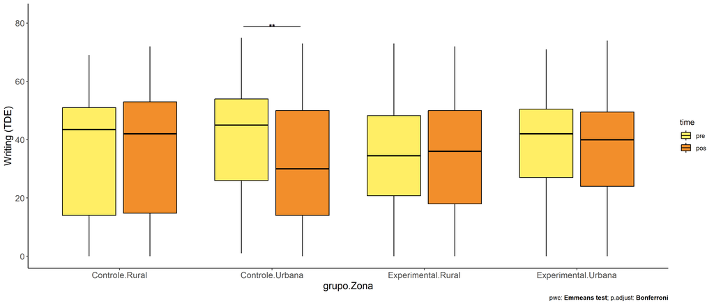

```r
if (length(unique(pdat[["Zona"]])) >= 2)
  plots[["grupo:Zona"]] + ggplot2::ylab("Writing (TDE)") +
    if (ymin < ymax) ggplot2::ylim(ymin, ymax)
```

### Checking linearity assumption

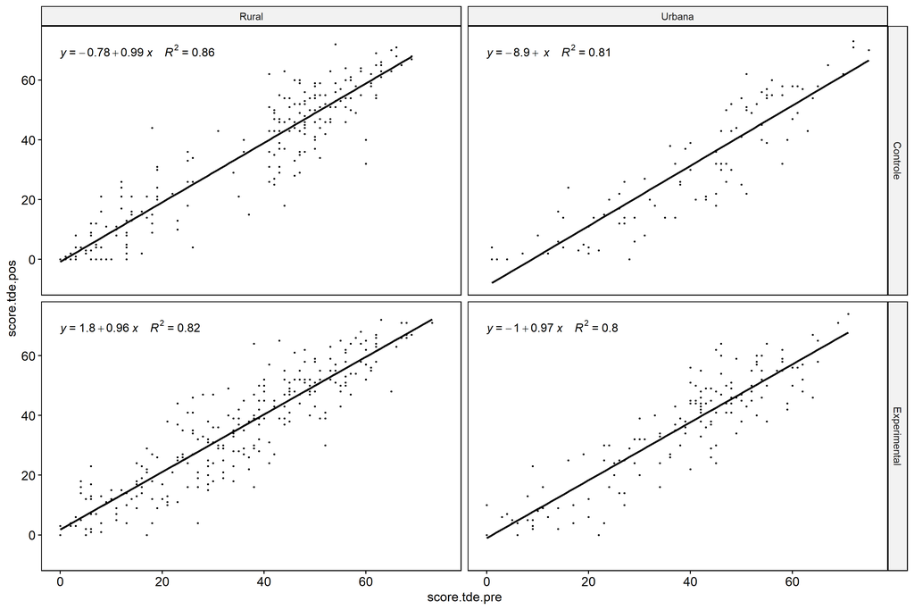

```r
if (length(unique(pdat[["Zona"]])) >= 2) {
  ggscatter(wdat, x = "score.tde.pre", y = "score.tde.pos", size = 0.5,
            facet.by = c("grupo","Zona"), add = "reg.line")+
    stat_regline_equation(
      aes(label =  paste(..eq.label.., ..rr.label.., sep = "~~~~"))
    ) +
    if (ymin < ymax) ggplot2::ylim(ymin, ymax)
}
```

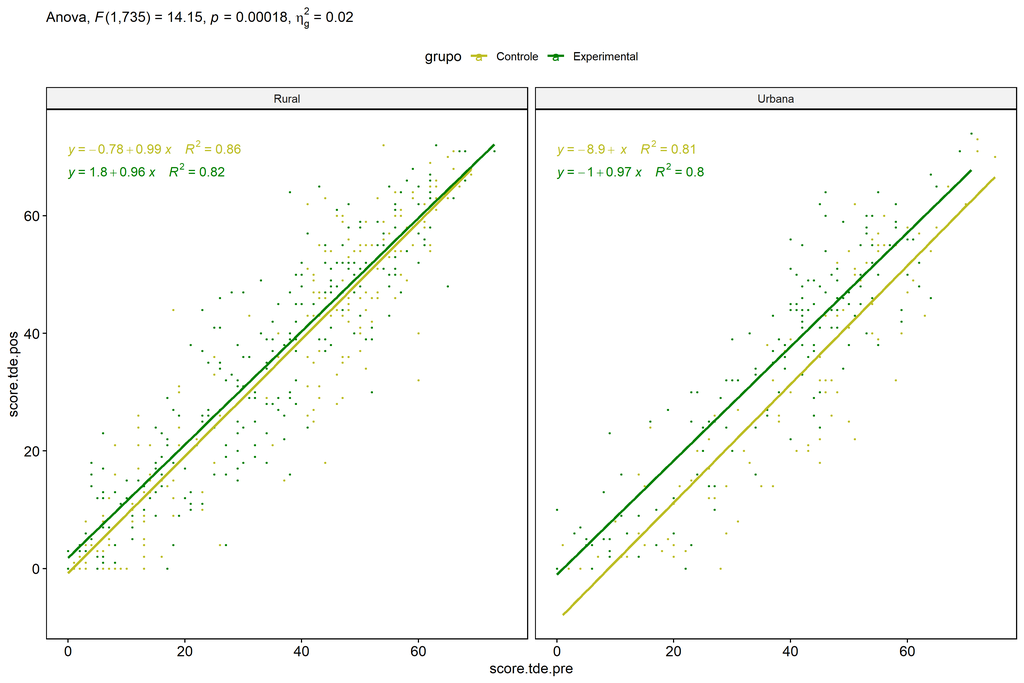

```r
if (length(unique(pdat[["Zona"]])) >= 2) {
  ggscatter(wdat, x = "score.tde.pre", y = "score.tde.pos", size = 0.5,
            color = "grupo", facet.by = "Zona", add = "reg.line")+
    stat_regline_equation(
      aes(label =  paste(..eq.label.., ..rr.label.., sep = "~~~~"), color = grupo)
    ) +
    ggplot2::labs(subtitle = rstatix::get_test_label(aov, detailed = T, row = which(aov$Effect == "grupo:Zona"))) +
    ggplot2::scale_color_manual(values = color[["grupo"]]) +
    if (ymin < ymax) ggplot2::ylim(ymin, ymax)
}
```

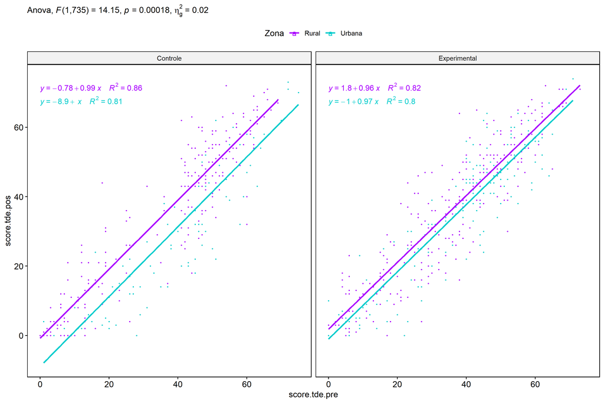

```r
if (length(unique(pdat[["Zona"]])) >= 2) {
  ggscatter(wdat, x = "score.tde.pre", y = "score.tde.pos", size = 0.5,
            color = "Zona", facet.by = "grupo", add = "reg.line")+
    stat_regline_equation(
      aes(label =  paste(..eq.label.., ..rr.label.., sep = "~~~~"), color = Zona)
    ) +
    ggplot2::labs(subtitle = rstatix::get_test_label(aov, detailed = T, row = which(aov$Effect == "grupo:Zona"))) +
    ggplot2::scale_color_manual(values = color[["Zona"]]) +
    if (ymin < ymax) ggplot2::ylim(ymin, ymax)
}
```